# Spur_Impact

Eric Hedberg

2023-06-28

## How I rigged it

The chance of treatment assignment is based on the math scores z-score.

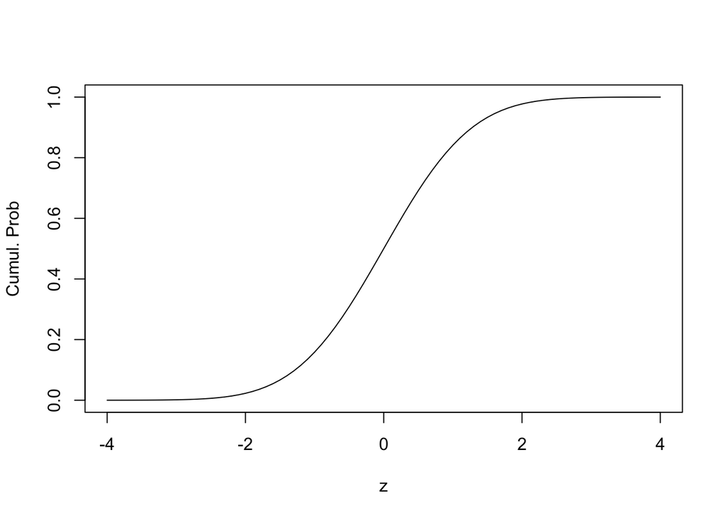

```r
plot(seq(from = -4, to = 4, by = .1), pnorm(seq(from = -4, to = 4, by = .1)), type = "l", ylab = "Cumul. Prob", xlab = "z")
```

and you see that in the code `pnorm(scale(data$math)-1)` below (I add a bit of an offset with the `-1`). Note that I do not build in any “treatment effect,” so whatever we see is an “echo” of math.

```r
data$treat <- rbinom(100,1,pnorm(scale(data$math)-1))

summary(lm(science ~ treat + math +ses+nonwhite, data = data))$coef
```

```
##              Estimate Std. Error    t value     Pr(>|t|)
## (Intercept) 4.5790357 4.83914863  0.9462482 3.464226e-01
## treat       2.4504532 1.15405252  2.1233463 3.632357e-02
## math        0.9873297 0.09043178 10.9179504 1.834403e-18
## ses         0.5555320 1.35467183  0.4100861 6.826661e-01
## nonwhite    0.1463454 1.31612401  0.1111942 9.116969e-01
```

Next, I wrote a quick function to help do this many times

```r
spur_impact <- function(data){
  data$treat <- rbinom(100,1,pnorm(scale(data$math)-1))
  coefs <- summary(lm(science ~ treat + math +ses+nonwhite, data = data))$coef
  rawcoefs <- summary(lm(science ~ treat, data = data))$coef

  return(cbind(b_c = coefs[2,1], p_c = coefs[2,4],b_uc = rawcoefs[2,1], p_uc = rawcoefs[2,4]))
}
```

So, we can do this a thousand times.

```r
results <- data.frame(t(replicate(1000,spur_impact(data), simplify = TRUE)))
```

If we don’t control for the math which, the placebo treatment effect is always significant

```r
mean(results$X4 <= .05)
```

```
## [1] 1
```

But we if we control for it, it can happen, but not a lot

```r
mean(results$X2 <= .05)
```

```
## [1] 0.03
```

Finally, suppose there was a treatment effect of .5, and it was related to something you didn’t measure and sorta correlated with what you have. This new function does this

```r
unobs_spur_impact <- function(data){
  other_var <- scale(rnorm(data$math*.15+data$ses*(-.05)+data$nonwhite*(.05))+rnorm(100))
  treat_effect <- runif(100, .25,.75)
  data$treat <- rbinom(100,1,pnorm(other_var))
  data$science <- data$science+treat_effect*data$treat
  coefs <- summary(lm(science ~ treat + math +ses+nonwhite, data = data))$coef
  rawcoefs <- summary(lm(science ~ treat, data = data))$coef

  return(cbind(b_c = coefs[2,1], p_c = coefs[2,4],b_uc = rawcoefs[2,1], p_uc = rawcoefs[2,4]))
}
```

So, we can do this a thousand times.

```r
results <- data.frame(t(replicate(1000,unobs_spur_impact(data), simplify = TRUE)))
```

```r
mean(results$X4 <= .05)
```

```
## [1] 0.073
```

But we if we control for it, it can happen more often

```r
mean(results$X2 <= .05)
```

```
## [1] 0.074
```